# assignment_2

u7457284 and Shiqi Hu

2022-10-30

# 1. Correct analysis of Clark et al. (2020) data (i.e., OA_activitydat_20190302_BIOL3207.csv) to generate the summary statistics (means, SD, N) for each of the fish species’ average activity for each treatment.

### By adding the link in the `()` brackets it will hyperlink “My GitHub Repository”. This is how to hyperlink in Rmarkdown documents.

[My GitHub Repository](https://github.com/JessicaHu119/Shiqi-Hu_assigenment2.git)

### Read all files

```r
library(tidyverse)
OA <- read_csv("./Data/OA_activitydat_20190302_BIOL3207.csv")
```

```
## ──────────────────────────────────────────────────────── Delimiter: "," chr
## (5): loc, species, treatment, size, comment dbl (4): ...1, animal_id, sl,
## activity
```

```r
clark_paper <- read_csv("./Data/clark_paper_data.csv")
ocean_meta <- read_csv("./Data/ocean_meta_data.csv")
```

### Calculate means, SD, N for each of the fish species’ average activity for each treatment

```r
data_OA <- OA %>% group_by(species, treatment) %>%
              summarise(mean = mean(activity, na.rm = TRUE),
                        sd = sd(activity, na.rm = TRUE),
                        n = length(unique(animal_id))) %>%
              rename(Species = "species")
```

# 2. Through coding, merge the summary statistics generated from 1) with the metadata (i.e., clark_paper_data.csv) from Clark et al. (2020).

```r
# Merge the table and add new columns and reduce rows
cb <- cbind(clark_paper, data_OA)
new <- pivot_wider(cb, names_from = treatment,
                     names_glue = "{treatment}_{.value}",
                     values_from = c("mean", "sd", "n"))
```

# 3. Through coding, correctly merge the combined summary statistics and metadata from Clark et al. (2020) (output from 1 & 2) into the larger meta-analysis dataset (i.e., ocean_meta_data.csv).

```r
# Displays the rows and columns of the table
dim(ocean_meta)
```

```
## [1] 818  22
```

```r
dim(new)
```

```
## [1]  6 22
```

### Do some renaming of colnames so they match ocean_meta

```r
# Rename the column
new1 <-  new %>% rename("oa.mean" = CO2_mean,
                            "oa.sd" = CO2_sd,
                            "oa.n" = CO2_n,
                            "ctrl.mean" = control_mean,
                            "ctrl.sd" = control_sd,
                            "ctrl.n" = control_n)
```

### Reorder col names based on names in ocean_meta

```r
new1 <- new1[names(ocean_meta)]
```

### Check columns are in same order

```r
colnames(ocean_meta) == colnames(new1)
```

```
##  [1] TRUE TRUE TRUE TRUE TRUE TRUE TRUE TRUE TRUE TRUE TRUE TRUE TRUE TRUE TRUE
## [16] TRUE TRUE TRUE TRUE TRUE TRUE TRUE
```

### Bind the two dataframes

```r
total <- rbind(ocean_meta, new1)
total <- total %>%  mutate(residual = 1:n())
total <- total[complete.cases(total),]
```

# 4. Correctly calculate the log response ratio (lnRR) effect size for every row of the dataframe using metafor’s escalc() function.

### Load the necessary R Packages

```r
library(pacman)
library(orchaRd)
```

### For’measure=“ROM” , the log is taken of the ratio of means, which makes this outcome measure symmetric around 0 and yields a coresponding sampling distribution that is closer to normality. Hence, this measure cannot be computed when ‘m1i’ and ‘m2i’ have opposite signs.

```r
lnRR <- metafor::escalc(measure = "ROM", m1i = ctrl.mean, m2i = oa.mean, sd1i = ctrl.sd, sd2i = oa.sd, n1i = ctrl.n, n2i = oa.n, data = total,
    var.names = c("lnRR", "V_lnRR"))
```

# 5. Correct meta-analytic model fitted to the data that controls for the sampling variance of lnRR. The model should include a random effect of study and observation. Use metafor’s rma.mv() function.

```r
#Integrated model
MLMA <- metafor::rma.mv( lnRR~1, V = V_lnRR, random=list(~1|Study, ~1|residual), method = "REML", test = "t", dfs = "contain", data=lnRR)
MLMA
```

```
##
## Multivariate Meta-Analysis Model (k = 795; method: REML)
##
## Variance Components:
##
##             estim    sqrt  nlvls  fixed    factor
## sigma^2.1  0.4792  0.6922     91     no     Study
## sigma^2.2  4.0497  2.0124    795     no  residual
##
## Test for Heterogeneity:
## Q(df = 794) = 736088678.9542, p-val < .0001
##
## Model Results:
##
## estimate      se     tval  df    pval    ci.lb   ci.ub
##  -0.1273  0.1140  -1.1162  90  0.2673  -0.3539  0.0993
##
## ---
## Signif. codes:  0 '***' 0.001 '**' 0.01 '*' 0.05 '.' 0.1 ' ' 1
```

# 6. Written paragraph of the findings and what they mean which is supported with a figure. The paragraph should include:

## Overall meta-analytic mean

We want to know what the overall meta-analytic mean effect size across the studies actually is estimated to be. We can see that from the model by extracting the intercept (labeled ‘estimate’ in the model output). Recall that the model is just an object that stores all the values for us.

If we want to convert the overall meta-analytic mean back to the correlation coefficient we can use the predict function to help with that. We can use the transf argument within the function:

```r
predict(MLMA, transf = "transf.ztor")
```

[output not shown]

There are LOTS of different transformations that can be done depending on which effect size you plan on using. Get familiar with the predict function and the transf argument by looking at it’s help file.

## Correct presentation and interpretation of overall meta-analytic mean and measures of uncertainty around the mean estimate (e.g., 95% confidence intervals).

### Measures of heterogeneity in effect size estimates across studies (i.e., I2 and/or prediction intervals - see predict() function in metafor)

```r
## Calculate I2
i2_vals <- orchaRd::i2_ml(MLMA)
## Make a pretty table. First, lets clean up the names of the different I2. Estimates. Lets remove I2_. It's a string, so, we can use some regular. Expressions to fix that. `gsub` is pretty useful. You put a pattern in and. Tell it what you would like to replace the text with. In this case, just. Blank will do! Then, we'll make the first letter of what is left, capitalised.
i2 <- tibble(type = firstup(gsub("I2_", "", names(i2_vals))), I2 = i2_vals)
i2
```

```
## # A tibble: 3 × 2
##   type        I2
##   <chr>    <dbl>
## 1 Total    100.
## 2 Study     10.6
## 3 Residual  89.4
```

```r
# Now, lets make a pretty table.
library(flextable)
```

```r
ft <- flextable(i2)%>%
    align(part = "header", align = "center") %>%
    compose(part = "header", j = 1, value = as_paragraph(as_b("Type"))) %>%
    compose(part = "header", j = 2, value = as_paragraph(as_b("I"), as_b(as_sup("2")),
        as_b("(%)")))
ft
```

| Type | I2(%) |
| --- | --- |
| Total | 100.00000 |
| Study | 10.58073 |
| Residual | 89.41927 |

Overall, we have highly heterogeneous effect size data because sampling variation only contributes to 0 of the total variation in effects.

## Forest plot showing the mean estimate, 95% confidence interval, and prediction interval with clearly labelled axes, number of samples and studies plotted on figure

There are some nice graphical approaches that capture the meta-analytic model results. We can use “orchard” plots which are modifications to what are called forest plots. We can do this with the orchaRd R package:

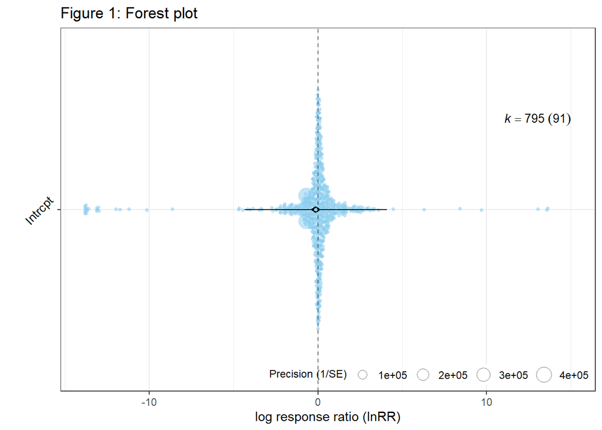

```r
# Make an orchard plot using the model object
orchaRd::orchard_plot(MLMA, mod = 1, group = "Study", data = lnRR,
    xlab = "log response ratio (lnRR)", angle = 45) + labs(title = "Figure 1: Forest plot")
```

# 7. Funnel plot for visually assessing the possibility of publication bias.

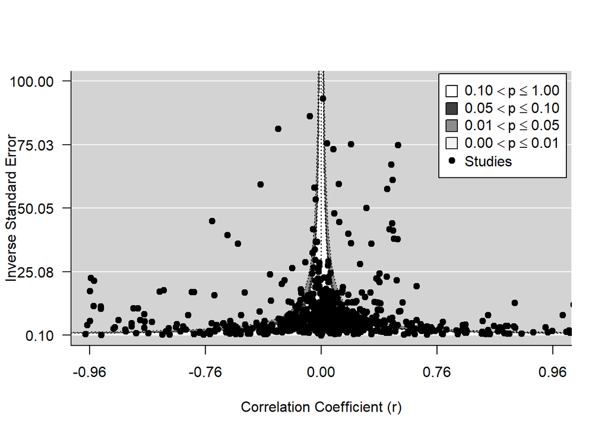

```r
# Lets make a funnel plot to visualize the data in relation to the precision,
metafor::funnel(x = lnRR$lnRR, vi = lnRR$V_lnRR, yaxis = "seinv", xlim = c(-2,2), ylim = c(0.1,100),
    digits = 2, level = c(0.1, 0.05, 0.01), shade = c("white", "gray25", "gray 55", "gray95"),
    las = 1, xlab = "Correlation Coefficient (r)", atransf = tanh, legend = TRUE, col="black")
```

Figure 2: Funnel plot depicting the correlation between lnRR and V_lnRR as a function of precision (1 / SE). The dotted lines are the theoretical 95% sampling variance intervals - the interval with which we expect effect size estimates to fall within if only sampling variance drives differences in effects. Shaded regions represent the p-value of studies. The white region indicates studies where the p-value is between 0.1 and 1; dark gray where the p-value of studies is between 0.05 and 0.1 and the lighter gray regions where the p-value of studies is significant.

We might expect under a file-drawer situation (i.e., where researchers stash away poorer quality studies showing opposite effects in their desk drawers) that studies with low power (i.e., low precision, wide standard errors, and small sample sizes) and non-significant correlations will go unpublished. This should be particularly true for studies that show the opposite to what we might predict by theory – specifically, negative correlations from studies with small sample sizes / low precision that are not significant. This is one factor that can drive what we call funnel asymmetry, showing a bunch of missing effect sizes in the bottom left corner of the funnel.